# Prosper Loan Data Set Exploration by Shiu-Tang Li

### 1. Introduction

```
## 'data.frame':    113937 obs. of  14 variables:
##  $ Term                   : int  36 36 36 36 36 60 36 36 36 36 ...
##  $ LoanStatus             : Factor w/ 12 levels "Cancelled","Chargedoff",..: 3 4 3 4 4 4 4 4 4 4 ...
##  $ BorrowerAPR            : num  0.165 0.12 0.283 0.125 0.246 ...
##  $ ProsperScore           : num  NA 7 NA 9 4 10 2 4 9 11 ...
##  $ ListingCategory        : int  0 2 0 16 2 1 1 2 7 7 ...
##  $ Occupation             : Factor w/ 68 levels "","Accountant/CPA",..: 37 43 37 52 21 43 50 29 24 24 ...
##  $ EmploymentStatus       : Factor w/ 9 levels "","Employed",..: 9 2 4 2 2 2 2 2 2 2 ...
##  $ CreditScoreRangeLower  : int  640 680 480 800 680 740 680 700 820 820 ...
##  $ CreditScoreRangeUpper  : int  659 699 499 819 699 759 699 719 839 839 ...
##  $ AmountDelinquent       : num  472 0 NA 10056 0 ...
##  $ DelinquenciesLast7Years: int  4 0 0 14 0 0 0 0 0 0 ...
##  $ IncomeVerifiable       : Factor w/ 2 levels "False","True": 2 2 2 2 2 2 2 2 2 2 ...
##  $ StatedMonthlyIncome    : num  3083 6125 2083 2875 9583 ...
##  $ LoanOriginalAmount     : int  9425 10000 3001 10000 15000 15000 3000 10000 10000 10000 ...
```

The main goal of this report is to apply exploratory data analysis techniques in order to analyze what types of borrowers will most likely complete a loan / fail to complete a loan.

#### 1.1 The structure of this report

In Section 2, I study a few individual variables, giving the reader some knowledge about the data set that we will be studying. In Section 3, I study how other factors influence the LoanStatus vairable, and also see if there’re connections between other variables. In Section 4, I perform multivariate analysis on a few variables at the same time, to see if a few different factors are combined together, could some interesting information be revealed from the data set? In Section 5, a few interesting plots are selected as the conclusion to this report, and Section 6 contains some thoughts of this whole project.

### 2. Univariate analysis

The variables I investigate in this report can be classfied into three categories: (1) background information of borrowers (2) current loan information (3) result (is the loan completed or not). Let’s have a look at some of these variables.

#### 2.1 background information of borrowers

**2.1.1. Occupation**

The following picture shows the number of applications by occupation. There’re 68 occupations including an empty occupation, and the top 36 occupations account for 95% of the total applications. We can see many applicants choose “Others”, which could be that they’re unemployed or they don’t want to disclose their personal information.

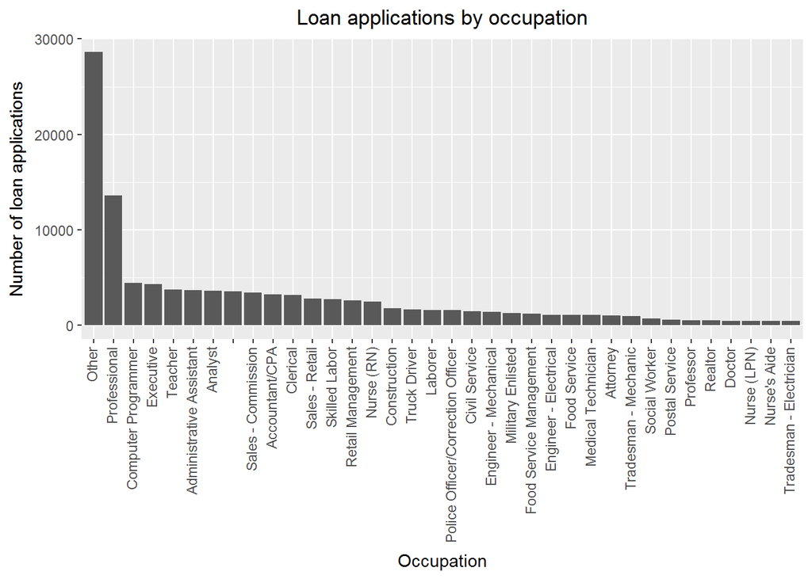

**2.1.2. Purpose of a loan**

People apply for loan for various reasons. The following figure shows the reader the distributions of it.

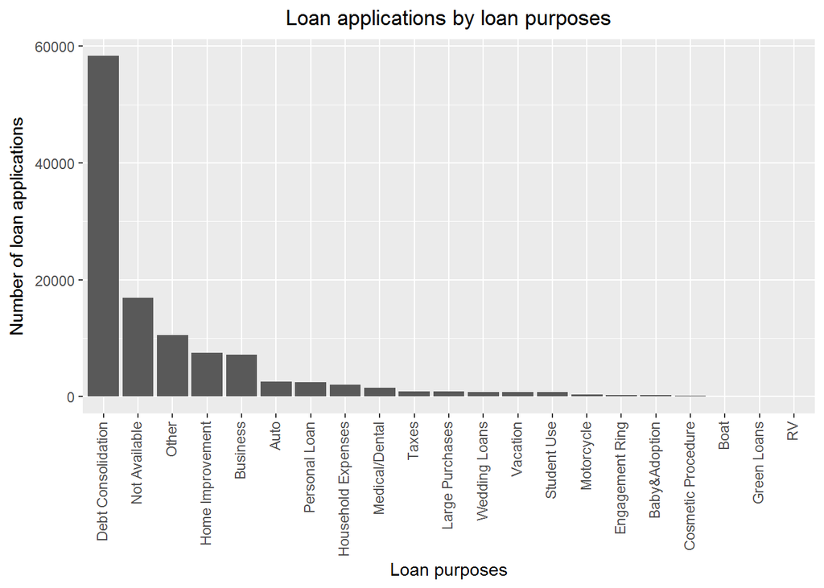

**2.1.3. Credit scores**

```
##    Min. 1st Qu.  Median    Mean 3rd Qu.    Max.    NA's
##     9.5   669.5   689.5   695.1   729.5   889.5     591
```

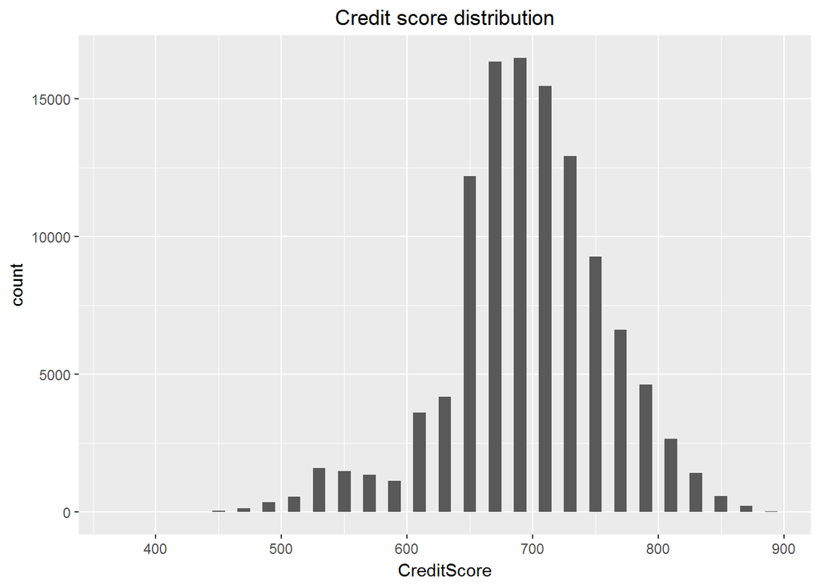

**2.1.4. Stated monthly income**

There’s one person in the data set reported that he / she has a monthly income of 1750000 dollars. I assume that this is a prank and removed it by discarding the top 0.5% of the data.

```
##    Min. 1st Qu.  Median    Mean 3rd Qu.    Max.
##       0    3200    4667    5608    6825 1750000
```

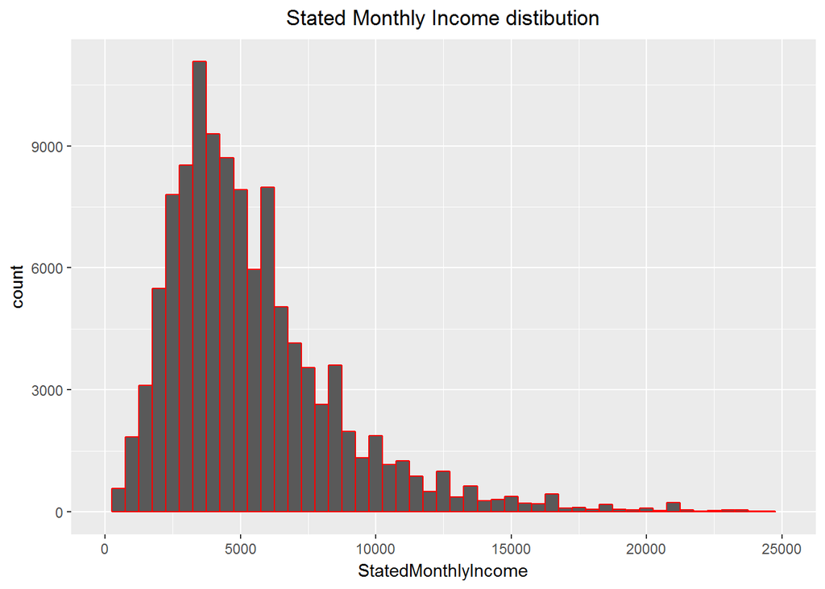

**2.1.5. Employment status**

There’re 9 different employment status, including “employed”, “not employed”, “full-time”, “part-time”, … and so on. Note that there’re ambiguous status like empty status, “not available”, and “others”.

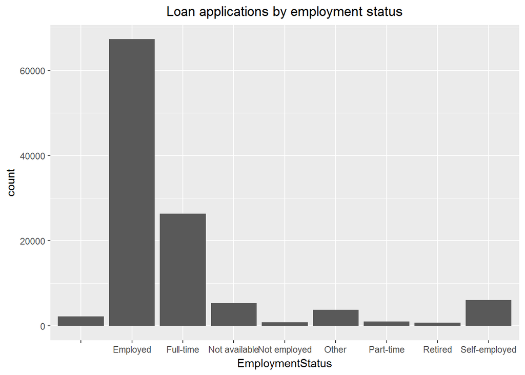

**2.1.6. Number of delinquencies in last 7 years**

Out of the 113,937 applications, there’re 76,439 applications without delinquencies in the last 7 years. The distribution of applications with at least 1 delinquency record is shown as follows (including the summary statistics for these 36,508 records). The blue vertical line indicates the average of it (including the records of zero delinquencies).

```
##    Min. 1st Qu.  Median    Mean 3rd Qu.    Max.
##    1.00    3.00    8.00   12.85   17.00   99.00
```

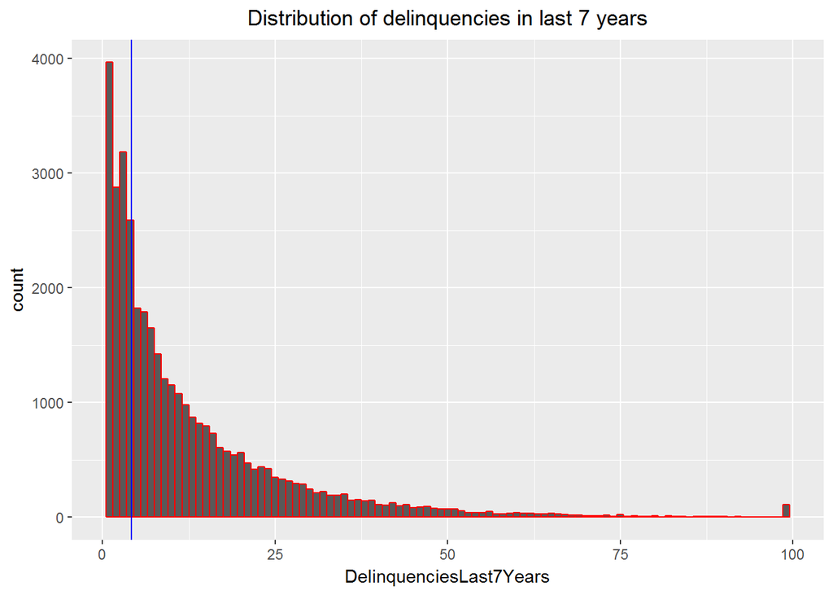

**2.1.7. Delinquency amount (in dolloars) when the credit file is pulled**

Out of the 113,937 loan records, there’re 7622 missing values, and 16,497 records with non-zero delinquency amounts. For theses 16,497 records, the summary and distribution are given as follows.

```
##    Min. 1st Qu.  Median    Mean 3rd Qu.    Max.
##       1     246    1067    6345    5061  463900
```

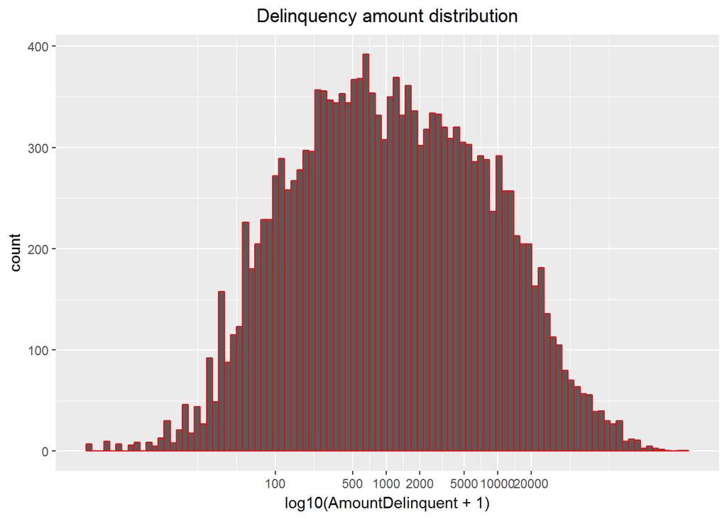

#### 2.2 Current loan information

**2.2.1 Loan terms**

There’re 3 different loan terms, 12, 36, or 60 months.

```
##
##    12    36    60
##  1614 87778 24545
```

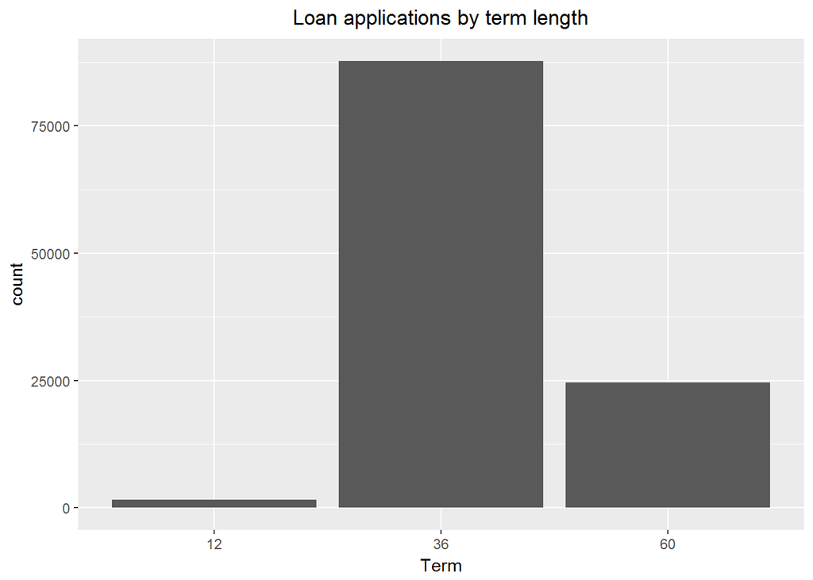

**2.2.2 Total loan amount**

The following figure shows the distribution of the original loan amount. The blue vertical line indicates the average.

```
##    Min. 1st Qu.  Median    Mean 3rd Qu.    Max.
##    1000    4000    6500    8337   12000   35000
```

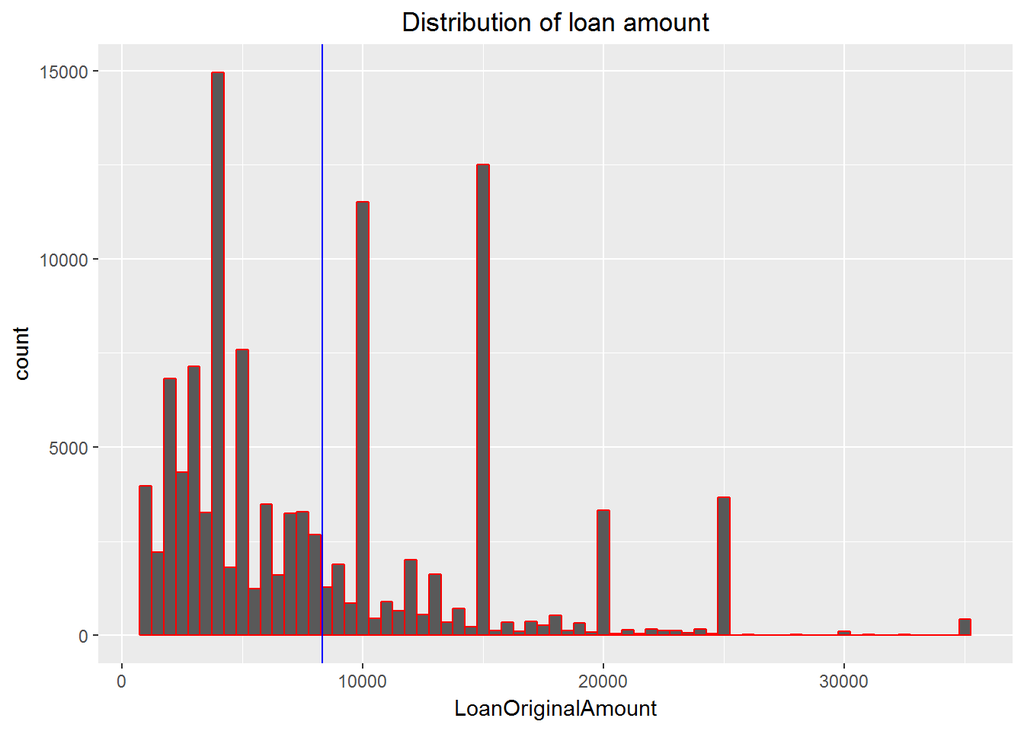

**2.2.3 Borrower’s APR (annual percentage rate)**

The following figure shows the distribution of the borrower’s APR. The blue vertical line indicates the average. 25 records of missing values (out of 113,937 records) are removed.

```
##    Min. 1st Qu.  Median    Mean 3rd Qu.    Max.    NA's
## 0.00653 0.15630 0.20980 0.21880 0.28380 0.51230      25
```

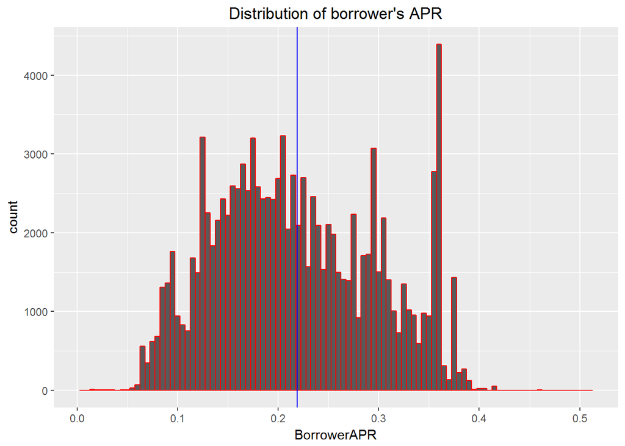

#### 2.3 Loan Status

There’re 12 different status of a loan, as shown in the following table. (log base 10 transformation is applied to ‘count’)

```
##
##              Cancelled             Chargedoff              Completed
##                      5                  11992                  38074
##                Current              Defaulted FinalPaymentInProgress
##                  56576                   5018                    205
##   Past Due (>120 days)   Past Due (1-15 days)  Past Due (16-30 days)
##                     16                    806                    265
##  Past Due (31-60 days)  Past Due (61-90 days) Past Due (91-120 days)
##                    363                    313                    304
```

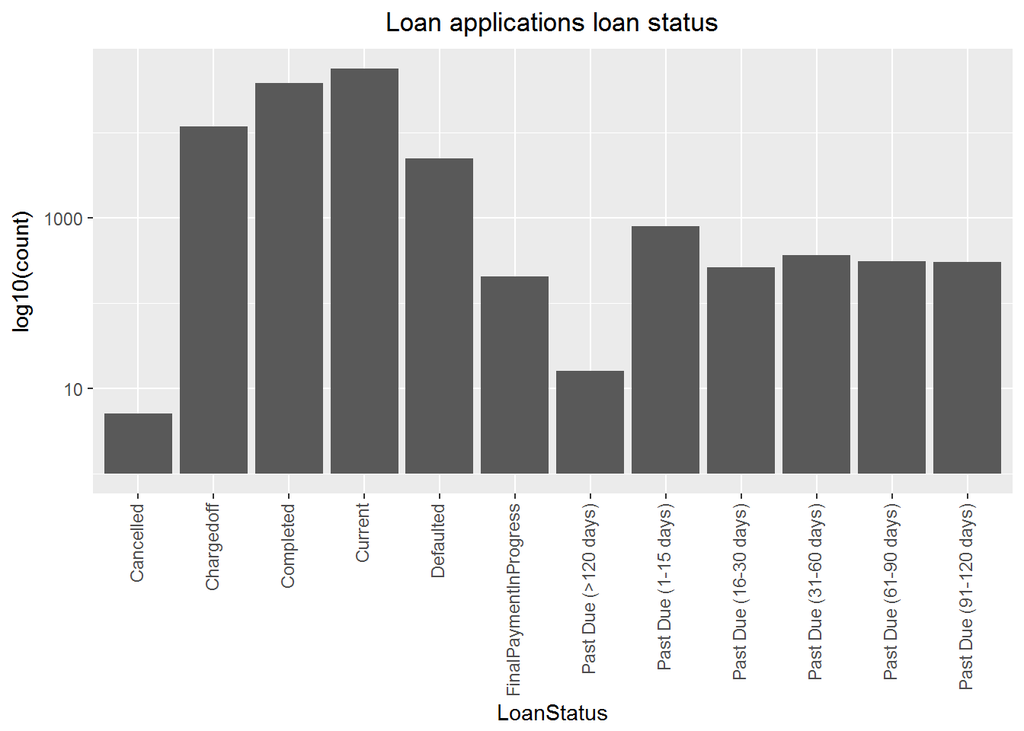

In this report, I create another variable “LoanStatus2” to combine loan status. “Chargedoff” and “Defaulted” are combined into a new status “Bad_ debt”, and “Completed” and “FinalPaymentInProgress” are combined into “Good_ debt”. The data with other labels are negelected (55289 loan records are left). The good debt ratio is 0.69234.

```
##
##  Bad_debt Good_debt
##     17010     38279
```

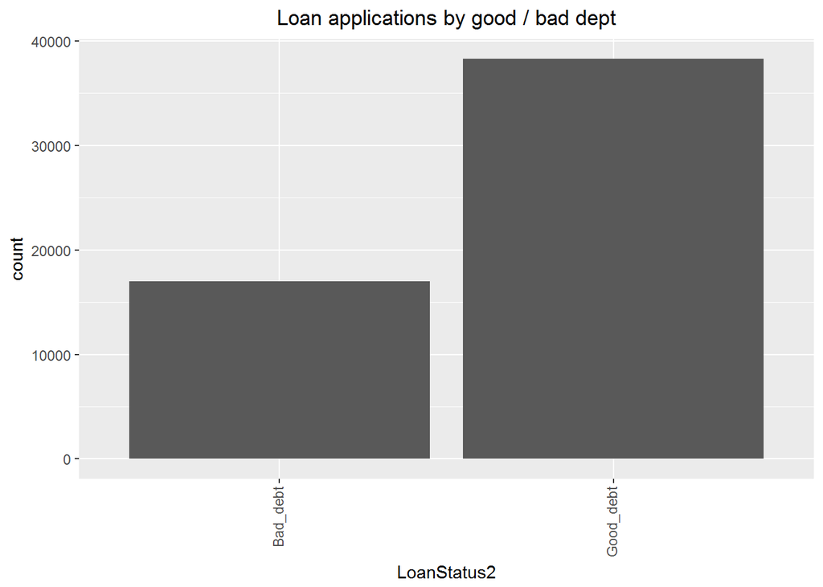

### 3. Bivariate analysis

#### 3.1 Plots that involve loan status

**3.1.1 How credit score affects loan status**

The following figures compare the distribution of credit scores by loan status. From the ratio plot we can see the credit score is very helpful for us to judge whether or not a loan will be completed or defaulted. I have removed 133 loan records with credit score 9.5 and 590 records with missing values.

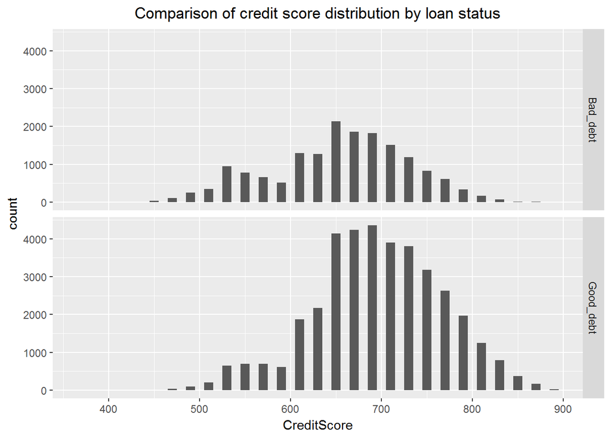

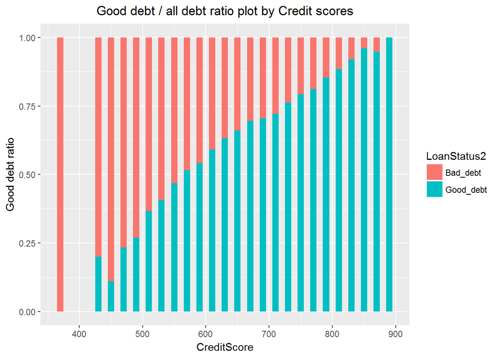

**3.1.2 Is ProsperScore accurate in predicting loan status?**

The following figures compare the distribution of Prosper Score (A custom risk score built using historical Prosper data) by loan status. It seems that the credit score is also helpful for us to judge whether or not a loan will be completed or defaulted.

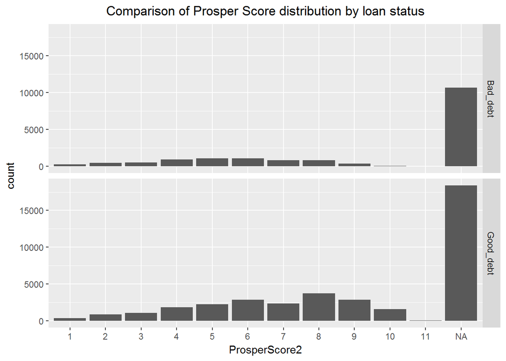

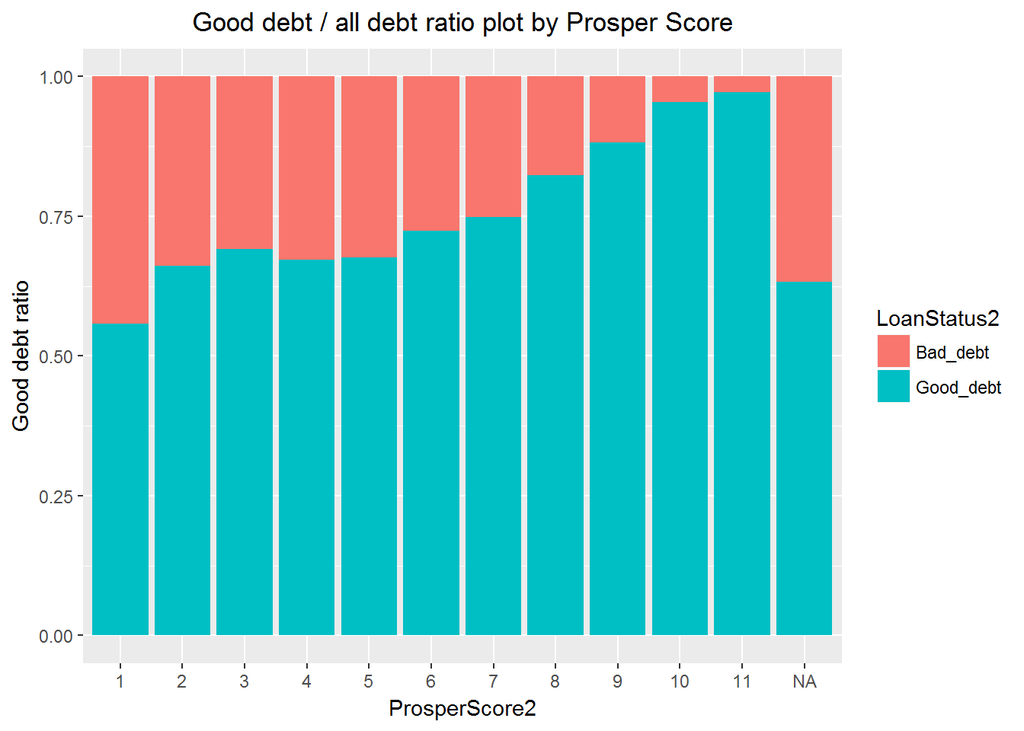

**3.1.3 Does stated monthly income determine loan status?**

The following figures compare the distribution of stated monthly income by loan status. It doesn’t seem that stated monthly income is useful in determining the loan status.

In the ratio plot, the ratio fluctuates a lot when stated monthly income is greater than $15000. I think this is because when don’t have enough data in these cases so the variance of the data is larger.

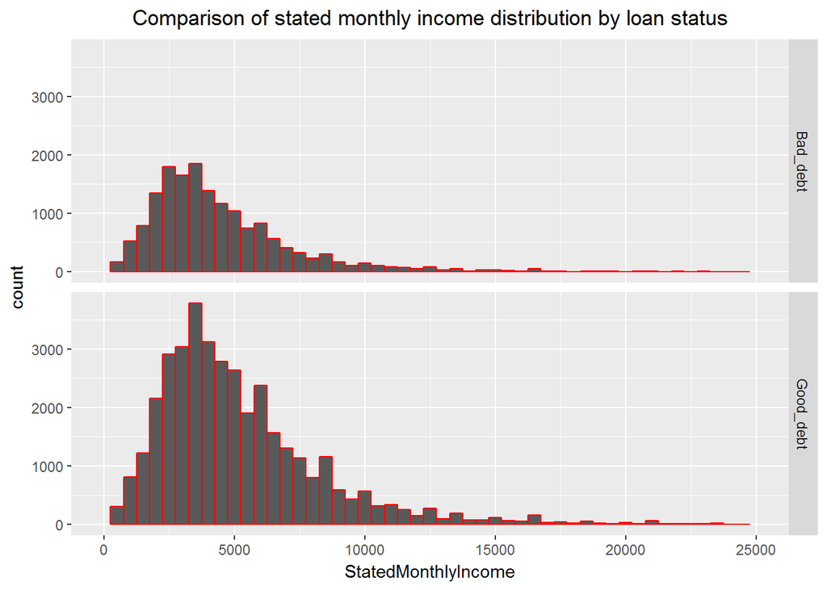

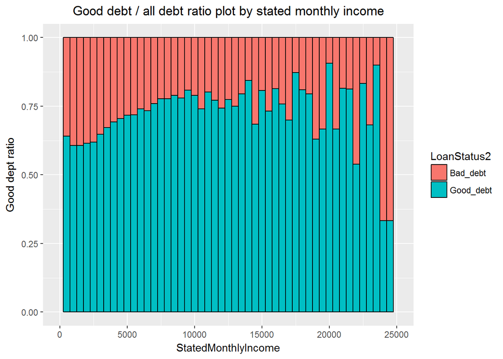

**3.1.4 Does employment status determine loan status?**

Some information shown in the ratio plot below is that the records of which that employment status is “Other” or “Not available” has quite low good debt rates. This can be viewed as a warning sign.

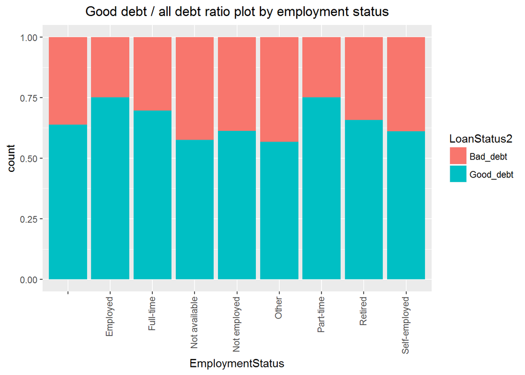

**3.1.5 Is loan amount a good indicator to show loan status?**

From the ratio plot the loan amount doesn’t seem like a good indicator to help identify loan status.

Something interesting is that there’re 18 record with loan amount greater than $25000, and these loans are all completed. My guess is to give such a high amount of loan to borrowers, the loan company must have checked very carefully.

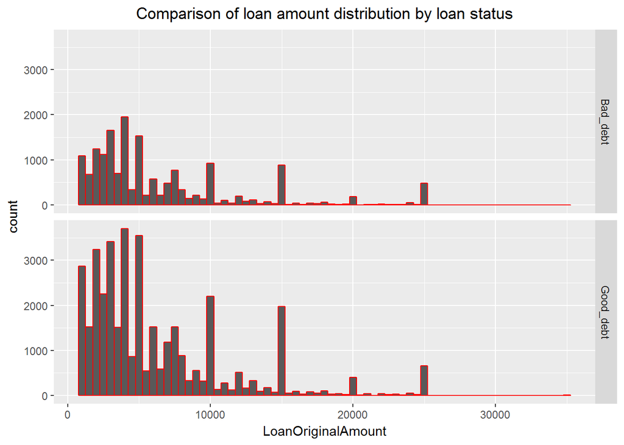

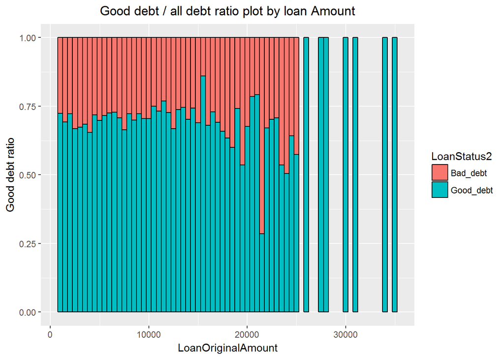

**3.1.6 Is loan term a good indicator to show loan status?**

From the figure below we can see when the term length is low it’s very likely that the loan will be completed. However, there’re not many cases where the term length is 12 months (The reader can check the univariate plot Section).

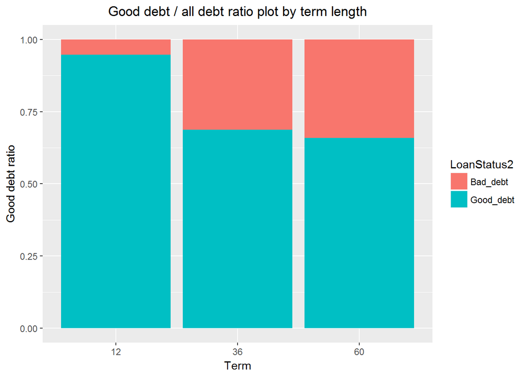

**3.1.7 Is the number of delinquencies in last 7 years of borrowers helpful in determining loan status?**

We did see when the number of delinquencies is smaller, the good debt ratio is higher. But when the number of delinquencies is high, it’s kind of diffcult to predit the good debt ratio. Again it might be because we have little data when the number of delinquenciesis high, so the variance of the data in this case is high.

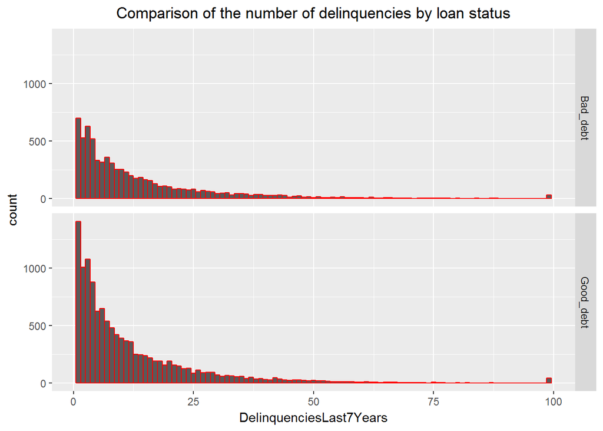

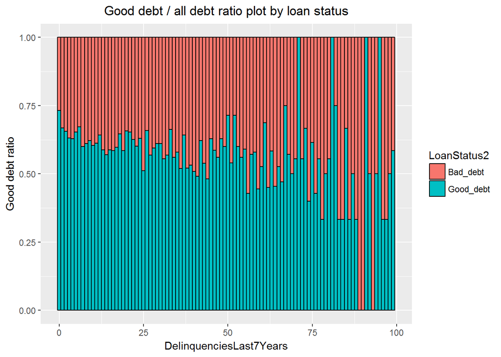

Let’s look at the box plot instead. Among the people who have delinquencies records, those who turn out to be bad debts tend to have higher delinquency numbers, but the trend is not obvious.

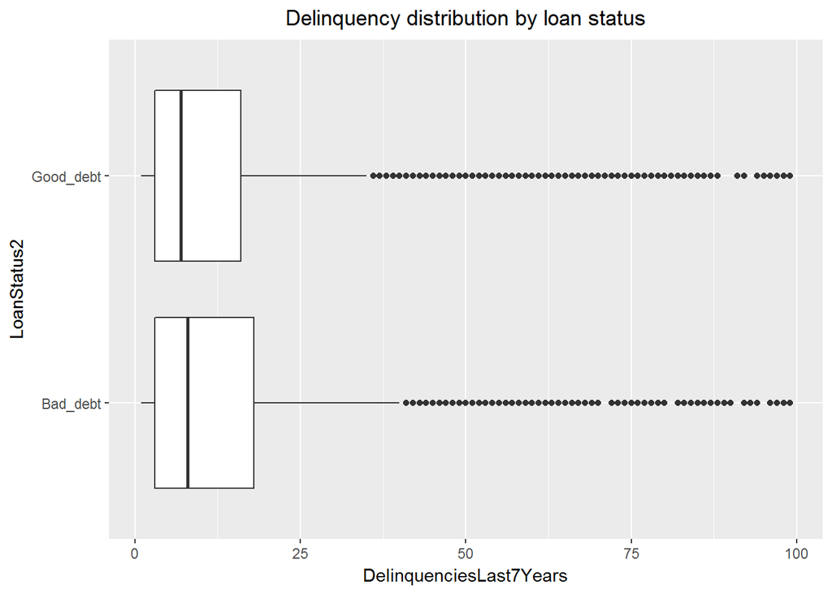

Let’s do a t-test to see if the difference of the number of delinquencies is significant. I assume the loans of good debts and bad debts are independent, normally distributed, with different mean and variance, so the Welch’s t test is applicable. From the test below we can see the p-value for the two groups (good debts and bad debts) having the same mean is super low, and this implies the mean is very likely to be different. But is the difference huge? Well, as the reader can see in the t test, a 99% confidence interval for the mean difference is (-2.0809152, -0.9404948), so the difference is actually quite small (but there is a difference though).

```
##
##  Welch Two Sample t-test
##
## data:  x and y
## t = -6.8253, df = 14381, p-value = 9.128e-12
## alternative hypothesis: true difference in means is not equal to 0
## 99 percent confidence interval:
##  -2.0809152 -0.9404948
## sample estimates:
## mean of x mean of y
##  12.21032  13.72102
```

**3.1.8 Borrower’s APR vs. loan status**

Let’s look at borrower’s APR distribution with different loan status (with full 12 status in detail). The reader can see higher APR is linked to higher default rate. But is it higher APR that causes higher default rate? Or is it because group of higher default rate usually have lower credit scores, so they receive higher APR when they start a loan?

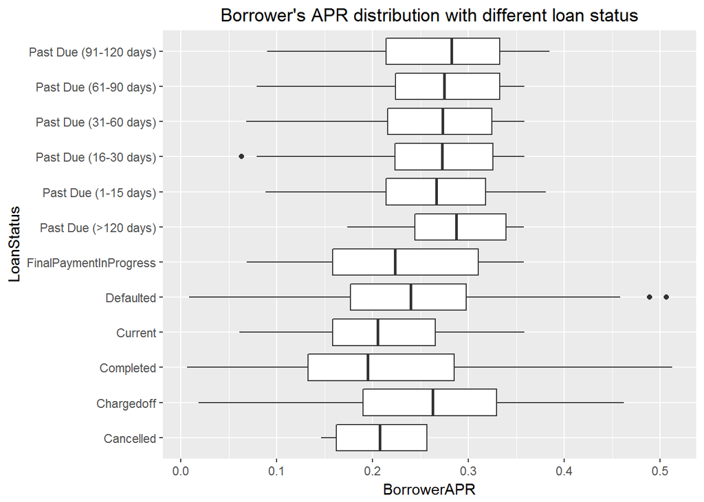

#### 3.2 plots that don’t involve loan status

**3.2.1 Borrower’s APR versus loan amount**

The following scatter plot shows the joint distribution of Borrower’s APR and loan amount. The data is focused on certain loan amounts, and small loan amounts, with Borrower’s APR lying between 0.1 and 0.3.

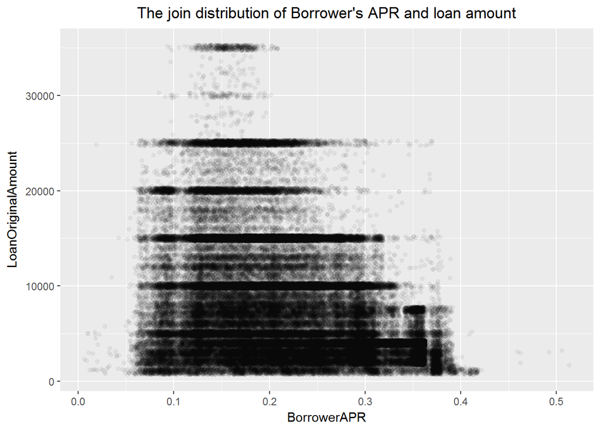

**3.2.2 Borrower’s APR versus credit scores**

We can see there’s a linear trend that fits the data. Higher credit scores are accompannied by lower APRs.

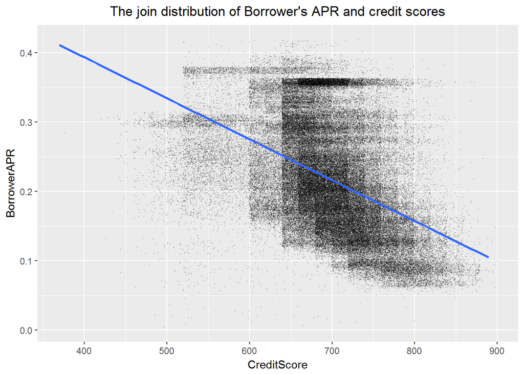

#### 3.3 Discussions

**3.3.1 Talk about some of the relationships you observed in this part of the investigation. How did the feature(s) of interest vary with other features in the dataset?

Say, from the previous section, loan term length is short -> good debt ratio gets high good debt ratio gets high <-> credit score is high

**3.3.2 Did you observe any interesting relationships between the other features?

Most interesting relationships I found was about how the loan status variable interact with other variables. There are some interesting connections between borrower’s APR and other variables, as shown in the plots.

### 4. Multivariate analysis

#### 4.1 Scatterplot matrix between continuous features used in this plot

First I include the scatterplot matrix of continuous features used in this report. As the reader can see not much information is obtained from this matirx: the scatterplots have to be tweaked; correlation is low. We have to put some constraints on the data set in order to dig more information.

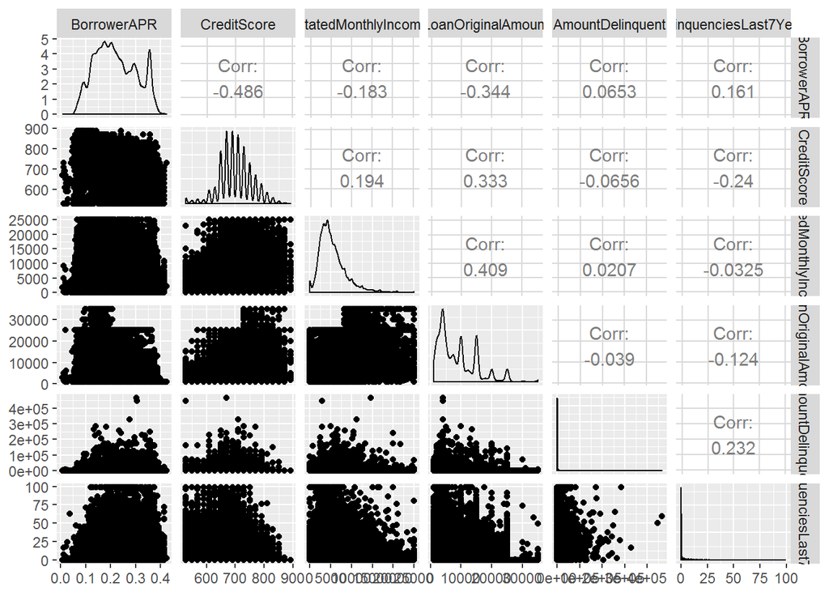

#### 4.2 incomeVerifiable, loan status, and loan amount

I’m curious about the effect of “IncomeVerifiable” variable (The borrower indicated they have the required documentation to support their income) on the loan amount by loan status. The reader can find that if the income of the borrower can be verified, the loan amount doesn’t differ much. However, if the income of the borrower CANNOT be verified, the loan amount of the bad debt record is larger than good debt records.

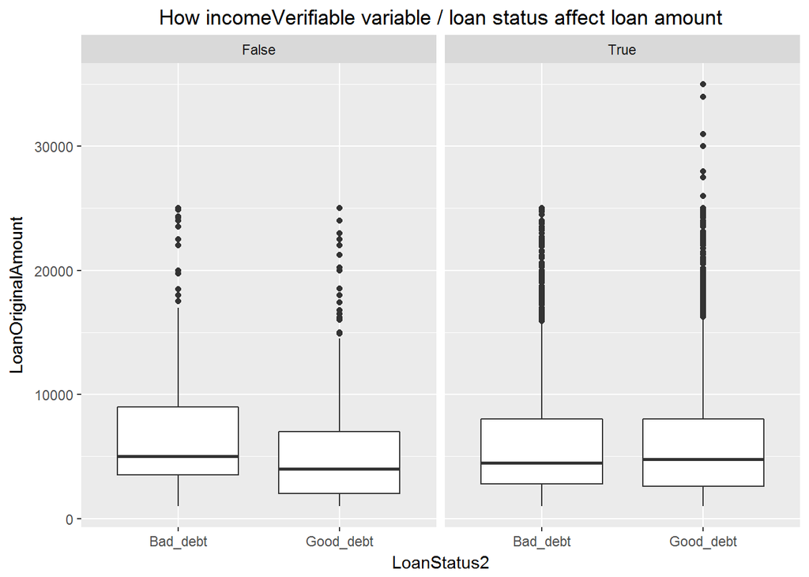

#### 4.3 CreditScore, ProsperScore, and loan status

The next thing I’m curious about is that if I combine two predictors (CreditScore, ProsperScore) together, would it give me a clearer idea to guess loan status? So I started with a scatter plot of CreditScore and ProsperScore, faceted by LoanStatus variable.

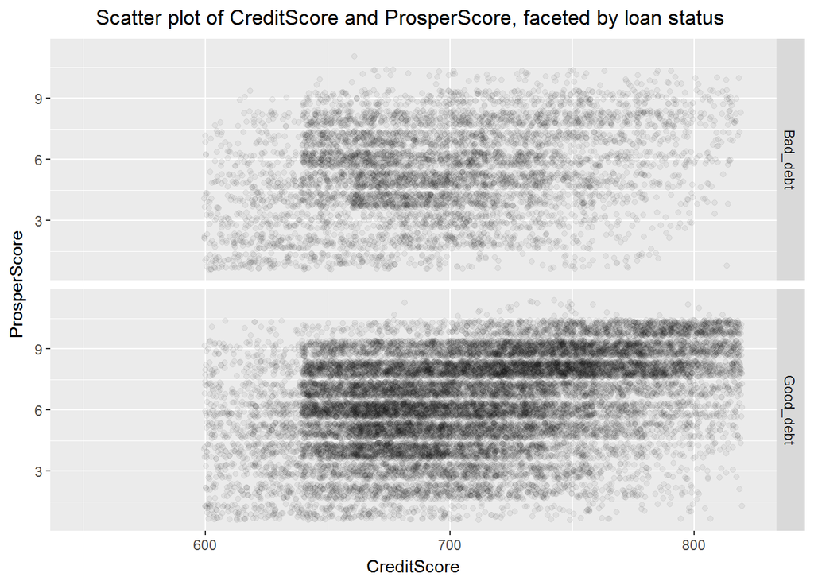

From the figure above I can roughly tell good debt racords focus more on higher credit scores. But what we want to know is to find the trend of good debt ratio. So I break both variables into quantile groups, and make a heat map. The color indicates good debt ratio.

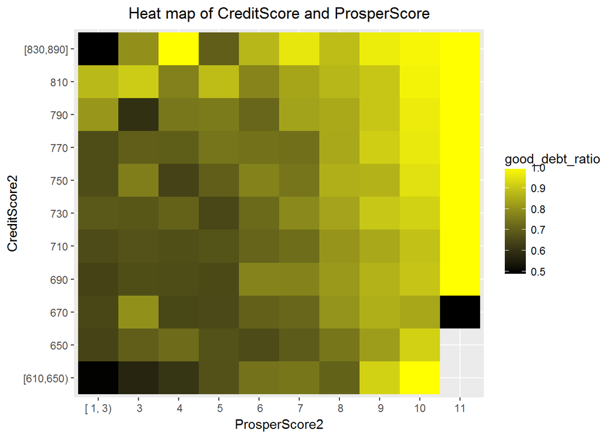